# A Network Meta-Analysis of Interventions for Students Struggling with Mathematics in Grades K-6

Author

Seth B. Morgan

**Project overview**

**Project description**

> - Title: A Network Meta-Analysis of Interventions for Students Struggling with Mathematics in Grades K-6
> - Purpose: Identify which multicomponent mathematics interventions are most associated with improved math outcomes amongst struggling grade school students.
> - Method: The project conducts a network meta-analysis of relevant, systematically reviewed research findings to estimate and rank the relative impact of multicomponent mathematics interventions on student-level math outcomes.
> - Significance: Provides evidence to stakeholders on the comparative effectiveness of multicomponent mathematics interventions, particularly amongst struggling grade school students.

**Goals**

> - **RQ: *Which types of multicomponent mathematics interventions most improve math outcomes amongst grade school students struggling in math?***
> - Fit a network meta-analysis to student-level math outcomes of struggling students receiving multicomponent mathematics interventions to identify which interventions are most associated with improved outcomes.
> - Disseminate findings to educators, administrators, and other key decision makers and stakeholders.

**Steps**

> 1. Systematic review:  
>    Conduct a systematic review of relevant research to identify high-quality, credible research to be included in the meta-analysis synthesis.
> 2. Network meta-analysis (NMA):  
>    Fit a network meta-analysis to the student-level outcomes of this research to identify the instructional practice combinations most associated with improved outcomes. -> disseminate findings in journal article
> 3. Component network meta-analysis (CNMA):  
>    Fit a component network meta-analysis to the student-level outcomes of this research to identify the individual instructional components most associated with improved outcomes. -> create tutorial for public access

**Role**

> - Co-led project with [Instructional Research Group](https://www.inresg.org/) & Dean of the College of Education at University of Oregon.
> - Individually led the development of all R scripts: data cleaning/wrangling, indicator creation, analysis, and visualization of findings.
> - Participated in the systematic review effort for identifying high-quality, credible research findings for inclusion in project.

**Methodology**

**Systematic review**

> - Identify relevant group‑design studies (studies that compare student-level outcomes for an intervention group against a comparison group) that estimate the effect of a multicomponent mathematics intervention on student-level math outcomes amongst grade schoolers struggling with math.
> - Keep only those studies that meet [What Works Clearinghouse](https://ies.ed.gov/ncee/wwc) evaluation design and analysis standards (i.e., rigorous, high-quality studies).
> - Each finding has been converted to a standardized measure of intervention effects, known as an effect size, so that outcome measures on different scales can be synthesized on a common scale.
> - Analysis database is therefore comprised of student-level outcomes (as effect sizes) nested within study contrasts (arms) nested within studies: 300 unique student-level effect estimates (from dozens of different outcome measures); within 77 contrasts; within 45 studies (evaluating a dozen of different interventions).

**Network meta-analysis**

> - *Meta-analysis*
>   - Meta‑analysis is a quantitative synthesis method that combines effect sizes from multiple independent studies to estimate a pooled average effect with greater precision than any single study.
>   - Meta‑analysis compares one intervention against one comparator at a time (e.g., A vs. B). It pools results only from studies that directly evaluate that specific contrast, so each comparison is analyzed in isolation.
> - *Network meta-analysis (NMA)*
>   - Network meta‑analysis (NMA) extends this by comparing three or more interventions simultaneously within a connected evidence network.
>   - NMA can synthesize in a single analysis both direct evidence (head‑to‑head trials) and indirect evidence across multiple comparisons.
>   - For example: A vs. C inferred through the connection (network) of A vs. B and B vs. C, allowing estimation of all pairwise effects even when some comparisons have never been tested directly.
> - *Advantages of NMA*:
>   - Indirect comparisons — NMA estimates effects between interventions lacking head‑to‑head trials (e.g., A vs. C via B).
>   - Simultaneous multi‑arm synthesis — integrates all interventions in one coherent model rather than running many separate analyses.
>   - Intervention ranking — produces hierarchies identifying which interventions are most effective (e.g., model estimates and p-scores).
>   - Greater precision — combining direct & indirect evidence expands the evidence base providing greater analytical precision in estimation.
>   - Efficient use of sparse evidence — leverages all available comparisons, even when direct evidence is limited.

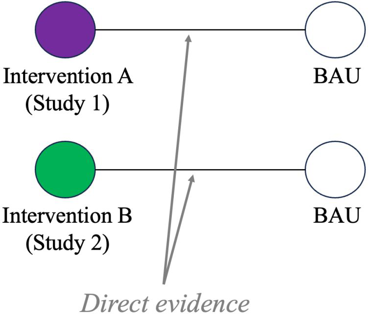

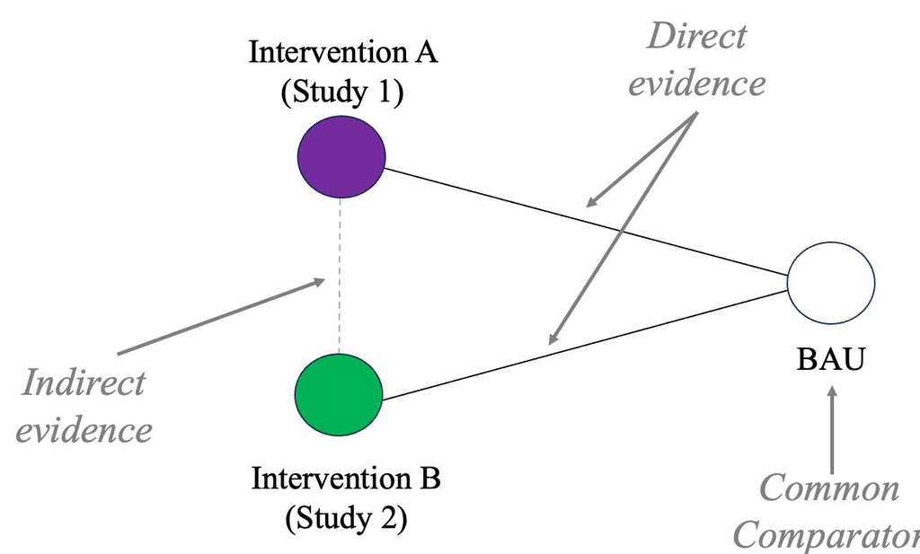

**Fitting the NMA**

> - *Challenges with education data*
>   - Dependencies in education meta‑analysis—multiple measures nested within contrasts (study arms) nested within studies—create correlated sampling errors, which biases model estimates if ignored in the analysis
>   - The R package *netmeta* assumes independence and therefore struggles with the multi‑level, multi‑measure data typical in education research
>   - The function [**rma.mv()**](https://wviechtb.github.io/metafor/reference/rma.mv.html) of the [*metafor*](https://wviechtb.github.io/metafor/index.html) package can model those dependencies directly, making it better suited for NMA in such contexts.
> - *metafor::rma.mv()*
>   - Interventions enter the analysis model as contrast-coded moderators (1, 0, -1) which encodes the entire treatment network and therefore turns the model into a network meta‑analysis.
>   - Interventions are component‑coded, meaning any interventions that share the same combination of instructional components enter the model under the same moderator. This approach identifies which component combinations are most effective and improves interpretability by reducing the noise created by many nominally different but structurally similar interventions.
>   - The fitted moderator coefficients become the pooled relative effects between interventions—estimated simultaneously using all direct and indirect evidence.
>   - “Business as usual” (BAU) serves as the reference category meaning the estimated coefficient on each moderator reflects how much more or less effective a given intervention (combination of instructional practices) is relative to BAU (measured in standard deviations).
>   - Larger coefficients—especially those estimated with greater precision—are ranked as more effective in the p‑score framework, which synthesizes both the magnitude of the estimated advantage over BAU and the certainty around that estimate.

```r
    ### Fit NMA model to outcomes in the Whole Numbers domain
    res_mod_icW <- rma.mv(effect_size, V_list,
                          mods = ~ FF + FF.RS + NL.FF.RS + NL.RS + RS + VF.FF.RS + VF.RS - 1, # BAU is excluded to serve as reference level
                          random = ~ 1 | record_id/es_id,
                          rho=0.60,
                          data=NMA_data_analysis_subset_grpID_icW)
```

**Findings**

**Whole Numbers domain**

> > Forest plot:

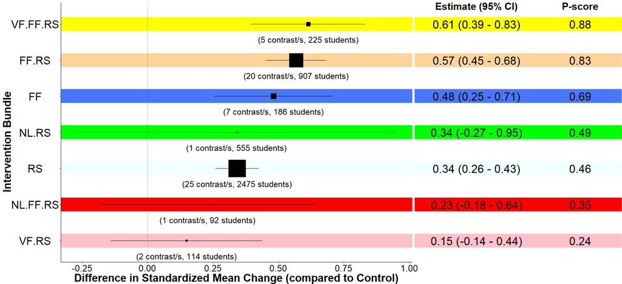

> > Network diagram:

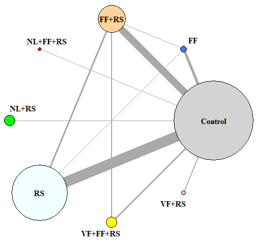

**Forest plot and network diagram for the whole numbers network meta-analysis (WN-NMA).**

Note. (A) Forest plot of all interventions versus the reference control, sorted by effect size. The effect estimates and confidence intervals incorporate both direct and indirect evidence from the network. p Scores indicate the ranking probability for each treatment, with higher scores representing a higher probability of being the most effective. (B) Network diagram of available direct comparisons. Node size is proportional to the number of participants, and connecting lines (edges) are proportional to the number of studies for each direct comparison.

**Rational Numbers domain**

> > Forest plot:

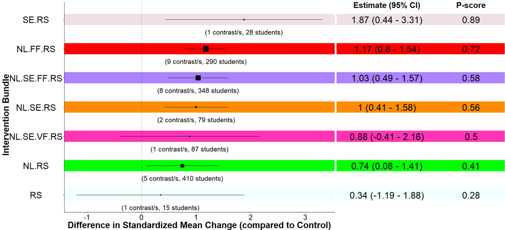

> > Network diagram:

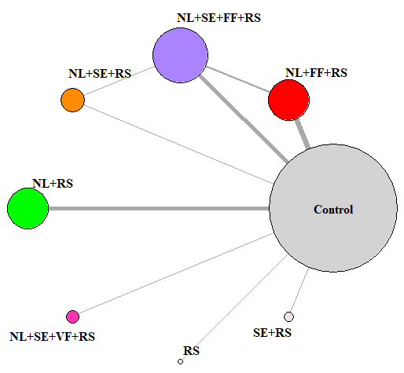

**Forest plot and network diagram for the rational numbers network meta-analysis (RN-NMA).**

Note. (A) Forest plot of all interventions versus the reference control, sorted by effect size. The effect estimates and confidence intervals incorporate both direct and indirect evidence from the network. p Scores indicate the ranking probability for each treatment, with higher scores representing a higher probability of being the most effective. (B) Network diagram of available direct comparisons. Node size is proportional to the number of participants, and connecting lines (edges) are proportional to the number of studies for each direct comparison.

**Dissemination**

> - Publication in journal [Review of Educational Research](https://www.aera.net/Publications/Journals/Review-of-Educational-Research):

> Jayanthi, M., Krowka, S., Schumacher, R. F., Morgan, S. B., Newman Gonchar, R., Schweer Collins, M., & Gersten, R. (2026). Exploring the relative value of combinations of instructional practices in mathematics interventions for grades K–6: An exploratory network meta analysis. Review of Educational Research. https://journals.sagepub.com/doi/10.3102/00346543261462183
> - R script on GitHub: NMA_metafor_allnodes_ic.R

**Next Steps**

> - CNMA: Fit a component network meta-analysis to the student-level outcomes of this research to identify the individual instructional components most associated with improved outcomes.
> - R script on GitHub: [CNMA_metafor_allnodes_ic.R](https://github.com/Instructional-Research-Group-IRG/CNMA/blob/main/cNMA_metafor.R)

```r
    ### Fit an additive CNMA model to outcomes in the Whole Numbers domain
    res_mod_icW_cnma <- rma.mv(effect_size, V_list,
                            mods = ~ FF + RS + NL + SE + VF - 1, # BAU is excluded to serve as the reference level for the comparisons.
                            random = ~ 1 | record_id/es_id,
                            rho=0.60,
                            data=cNMA_data_analysis_subset_grpID_icW)
    summary(res_mod_icW_cnma)
```

[output not shown]